# Project_1_CarPrice_Assignment

## Group 2- A

- Aiman Anwer
- Sai Niharika Hari
- Chandana Nandi

## Module 1 Project - Linear Regression

# The name of the project: Car Pricing Analysis

## 1. Objective of the Proposed Research

**a) Data Selection:**

**comprehensive** We have taken this Carprice dataset because our ultimate aim is to provide the stakeholder the accurate and useful informaton on the prices of the car and we wanted to give the entire data in a detailed way by describing all the aspects of the dataset. Here i described the model with price of the cars with the available independent variable.

- The Data set we have choosen is CarPrice_Assignment
- Explanation of the columns:
  - car_ID - Unique identifier for each car
  - symboling - Insurance risk rating(-3 to +3)
  - CarName - Name of the car model
  - fueltype - Type of fuel used(gas or disel)
  - aspiration - Type of aspiration(std or turbo)
  - doornumber- Number of Doors(2or4)
  - carbody - Body style of the car
  - drivewheel - Type of drive wheel(4wd,wd,or rwd)
  - enginelocation - Location of the engine9front or rear)
  - wheelbase - Distance between the front and rear axles
  - carlength - Length of the car
  - carwidth - width of the car
  - carheight - Height of the car
  - curbweight - Weight of the car without passengers or cargo
  - enginetype - Type of engine
  - cylindernumber - Number of cylinders in the engine
  - enginesize - Size of the engine
  - fuelsystem - Type of fuel injection system
  - boreratio - Bore ratio of the engine
  - stroke - Stroke length of the engine
  - compressionratio - Compression ratio of the engine
  - horsepower - Horsepower of the engine
  - peakrpm - Peak revolutions per minute
  - citympg - Miles per gallon in the city
  - highwaympg - Miles per gallon on the highway
  - price - price of the car

**b)Stakeholder** The stakeholders I have chose is **Business Owners/Executives.** It will be very useful for the Business owners to understand how exactly the prices vary with independent variables. This model will be a very good model for the executives to understand pricing dynamics of a new market.With the expected results from our report, the stakeholder that is Business Owners/executives will be able to understand the pricing of the cars compared to the various aspects.

Third, this research can assist business owners in making more informed fleet management decisions. This information, for example, can be used by business owners to determine when to replace vehicles in their fleet, how to improve vehicle utilization, and how to cut fuel expenditures. This study's major stakeholders are business owners and executives. The findings can help business owners make informed decisions about fleet purchases, car rentals, and other business-related expenses. The research can be used by executives to design firm rules and procedures around car utilization and fleet management.

Owners of businesses identify the finest automobile deals,more effectively budget for car expenses,make more informed fleet management decisions,create company policies and processes for car use and fleet management,reduce the costs of car ownership and operation at the workplace,increase employee satisfaction and productivity.The suggested research's overall goal is to equip business owners and executives with the knowledge they need to make informed decisions about automobile prices and fleet management. Business owners and executives can save money and boost their bottom lines by understanding how car prices vary depending on a range of factors.)

## 2. Data Exploration

# 1.Data Structure ('str(car_price)'):

'str()' is a R function which provides the framework of an object. It depicts the structure of the dataset 'car_price' in this case. This includes a description of the data types in each column as well as an overview of the first few observations in each column. It aids in comprehending the dataset's layout and content.

# 2.Statistics Summary (summary(car_price)):

In R, the 'summary()' function computes descriptive statistical data for each variable in the dataset. It provides numerical variables with mean, median, quartiles, and extremes (min, max), and categorical variables with counts of unique values. This summary aids in gaining an understanding of the numerical distributions and category variances in the dataset.

# 3.Examine for Missing Values (sum(is.na(car_price)):

is.na() is a function that checks a dataset for missing (NA) values. sum() is used to count the total number of missing values by adding the TRUE values (missing) returned by is.na(car_price). This stage is critical for finding any missing data in the dataset that will need to be dealt with during data preprocessing.

# 4.Check for Categorical Variables with Unique Values (table(car_price$fueltype)):

In R, the 'table()' function creates a frequency table of unique values for a given variable, in this instance the "fueltype" variable. It counts the number of times each unique value appears in the "fueltype" column. Recognizing unique values in categorical variables is critical for gaining insights into the dataset's diversity and distribution of categories.

```python
car_price <- read.csv("CarPrice_Assignment.csv")
head(car_price)
```

A data.frame: 6 × 26

|  | car_ID <int> | symboling <int> | CarName <chr> | fueltype <chr> | aspiration <chr> | doornumber <chr> | carbody <chr> | drivewheel <chr> | enginelocation <chr> | wheelbase <dbl> | ⋯ | enginesize <int> | fuelsystem <chr> | boreratio <dbl> | stroke <dbl> | compressionratio <dbl> | horsepower <int> | peakrpm <int> | citympg <int> | highwaympg <int> | price <dbl> |
| --- | --- | --- | --- | --- | --- | --- | --- | --- | --- | --- | --- | --- | --- | --- | --- | --- | --- | --- | --- | --- | --- |
| 1 | 1 | 3 | alfa-romero giulia | gas | std | two | convertible | rwd | front | 88.6 | ⋯ | 130 | mpfi | 3.47 | 2.68 | 9.0 | 111 | 5000 | 21 | 27 | 13495 |
| 2 | 2 | 3 | alfa-romero stelvio | gas | std | two | convertible | rwd | front | 88.6 | ⋯ | 130 | mpfi | 3.47 | 2.68 | 9.0 | 111 | 5000 | 21 | 27 | 16500 |
| 3 | 3 | 1 | alfa-romero Quadrifoglio | gas | std | two | hatchback | rwd | front | 94.5 | ⋯ | 152 | mpfi | 2.68 | 3.47 | 9.0 | 154 | 5000 | 19 | 26 | 16500 |
| 4 | 4 | 2 | audi 100 ls | gas | std | four | sedan | fwd | front | 99.8 | ⋯ | 109 | mpfi | 3.19 | 3.40 | 10.0 | 102 | 5500 | 24 | 30 | 13950 |
| 5 | 5 | 2 | audi 100ls | gas | std | four | sedan | 4wd | front | 99.4 | ⋯ | 136 | mpfi | 3.19 | 3.40 | 8.0 | 115 | 5500 | 18 | 22 | 17450 |
| 6 | 6 | 2 | audi fox | gas | std | two | sedan | fwd | front | 99.8 | ⋯ | 136 | mpfi | 3.19 | 3.40 | 8.5 | 110 | 5500 | 19 | 25 | 15250 |

```python
# 1. Structure of the data
str(car_price)

# 2. Summary statistics
summary(car_price)

# 3. Check for missing values
sum(is.na(car_price))

# 4. unique values for categorical variables
table(car_price$fueltype)
```

```
'data.frame':	205 obs. of  26 variables:
 $ car_ID          : int  1 2 3 4 5 6 7 8 9 10 ...
 $ symboling       : int  3 3 1 2 2 2 1 1 1 0 ...
 $ CarName         : chr  "alfa-romero giulia" "alfa-romero stelvio" "alfa-romero Quadrifoglio" "audi 100 ls" ...
 $ fueltype        : chr  "gas" "gas" "gas" "gas" ...
 $ aspiration      : chr  "std" "std" "std" "std" ...
 $ doornumber      : chr  "two" "two" "two" "four" ...
 $ carbody         : chr  "convertible" "convertible" "hatchback" "sedan" ...
 $ drivewheel      : chr  "rwd" "rwd" "rwd" "fwd" ...
 $ enginelocation  : chr  "front" "front" "front" "front" ...
 $ wheelbase       : num  88.6 88.6 94.5 99.8 99.4 ...
 $ carlength       : num  169 169 171 177 177 ...
 $ carwidth        : num  64.1 64.1 65.5 66.2 66.4 66.3 71.4 71.4 71.4 67.9 ...
 $ carheight       : num  48.8 48.8 52.4 54.3 54.3 53.1 55.7 55.7 55.9 52 ...
 $ curbweight      : int  2548 2548 2823 2337 2824 2507 2844 2954 3086 3053 ...
 $ enginetype      : chr  "dohc" "dohc" "ohcv" "ohc" ...
 $ cylindernumber  : chr  "four" "four" "six" "four" ...
 $ enginesize      : int  130 130 152 109 136 136 136 136 131 131 ...
 $ fuelsystem      : chr  "mpfi" "mpfi" "mpfi" "mpfi" ...
 $ boreratio       : num  3.47 3.47 2.68 3.19 3.19 3.19 3.19 3.19 3.13 3.13 ...
 $ stroke          : num  2.68 2.68 3.47 3.4 3.4 3.4 3.4 3.4 3.4 3.4 ...
 $ compressionratio: num  9 9 9 10 8 8.5 8.5 8.5 8.3 7 ...
 $ horsepower      : int  111 111 154 102 115 110 110 110 140 160 ...
 $ peakrpm         : int  5000 5000 5000 5500 5500 5500 5500 5500 5500 5500 ...
 $ citympg         : int  21 21 19 24 18 19 19 19 17 16 ...
 $ highwaympg      : int  27 27 26 30 22 25 25 25 20 22 ...
 $ price           : num  13495 16500 16500 13950 17450 ...
```

```
     car_ID      symboling         CarName            fueltype
 Min.   :  1   Min.   :-2.0000   Length:205         Length:205
 1st Qu.: 52   1st Qu.: 0.0000   Class :character   Class :character
 Median :103   Median : 1.0000   Mode  :character   Mode  :character
 Mean   :103   Mean   : 0.8341
 3rd Qu.:154   3rd Qu.: 2.0000
 Max.   :205   Max.   : 3.0000
  aspiration         doornumber          carbody           drivewheel
 Length:205         Length:205         Length:205         Length:205
 Class :character   Class :character   Class :character   Class :character
 Mode  :character   Mode  :character   Mode  :character   Mode  :character



 enginelocation       wheelbase        carlength        carwidth
 Length:205         Min.   : 86.60   Min.   :141.1   Min.   :60.30
 Class :character   1st Qu.: 94.50   1st Qu.:166.3   1st Qu.:64.10
 Mode  :character   Median : 97.00   Median :173.2   Median :65.50
                    Mean   : 98.76   Mean   :174.0   Mean   :65.91
                    3rd Qu.:102.40   3rd Qu.:183.1   3rd Qu.:66.90
                    Max.   :120.90   Max.   :208.1   Max.   :72.30
   carheight       curbweight    enginetype        cylindernumber
 Min.   :47.80   Min.   :1488   Length:205         Length:205
 1st Qu.:52.00   1st Qu.:2145   Class :character   Class :character
 Median :54.10   Median :2414   Mode  :character   Mode  :character
 Mean   :53.72   Mean   :2556
 3rd Qu.:55.50   3rd Qu.:2935
 Max.   :59.80   Max.   :4066
   enginesize     fuelsystem          boreratio        stroke
 Min.   : 61.0   Length:205         Min.   :2.54   Min.   :2.070
 1st Qu.: 97.0   Class :character   1st Qu.:3.15   1st Qu.:3.110
 Median :120.0   Mode  :character   Median :3.31   Median :3.290
 Mean   :126.9                      Mean   :3.33   Mean   :3.255
 3rd Qu.:141.0                      3rd Qu.:3.58   3rd Qu.:3.410
 Max.   :326.0                      Max.   :3.94   Max.   :4.170
 compressionratio   horsepower       peakrpm        citympg
 Min.   : 7.00    Min.   : 48.0   Min.   :4150   Min.   :13.00
 1st Qu.: 8.60    1st Qu.: 70.0   1st Qu.:4800   1st Qu.:19.00
 Median : 9.00    Median : 95.0   Median :5200   Median :24.00
 Mean   :10.14    Mean   :104.1   Mean   :5125   Mean   :25.22
 3rd Qu.: 9.40    3rd Qu.:116.0   3rd Qu.:5500   3rd Qu.:30.00
 Max.   :23.00    Max.   :288.0   Max.   :6600   Max.   :49.00
   highwaympg        price
 Min.   :16.00   Min.   : 5118
 1st Qu.:25.00   1st Qu.: 7788
 Median :30.00   Median :10295
 Mean   :30.75   Mean   :13277
 3rd Qu.:34.00   3rd Qu.:16503
 Max.   :54.00   Max.   :45400
```

0

```
diesel    gas
    20    185
```

## 3.Data Cleaning

1.Remove Rows with Missing Values : **'na.omit()'** is a function in R that removes rows with any missing (NA) values from the dataset 'car_price'. The resulting dataset with no missing values is assigned to a new variable 'cp_info'.

2.Remove Columns with No Useful Information : This line removes a specific column named "car_ID" from the dataset '**cp_info**'. '**names(cp_info)**' retrieves the column names of the dataset '**cp_info**'. '**%in% c("car_ID")**' checks if "car_ID" is present in the column names. '**!(...)**' negates the logical condition, so it selects columns that are not "car_ID". '**cp_info[, ...]**' selects and retains only the columns that are not "car_ID" in the dataset.

3.Display the First 10 Rows : '**head()**' function is used to display the first 10 rows of the dataset cp_info. This helps to preview the cleaned dataset and understand its structure after removing rows with missing values and the "car_ID" column.

```python
# Remove rows with missing values
cp_info <- na.omit(car_price)

# Remove columns with no useful information (here i am assuming 'car_ID' as an example)
cp_info <- cp_info[, !(names(cp_info) %in% c("car_ID"))]
head(cp_info, 10)
```

A data.frame: 10 × 25

|  | symboling <int> | CarName <chr> | fueltype <chr> | aspiration <chr> | doornumber <chr> | carbody <chr> | drivewheel <chr> | enginelocation <chr> | wheelbase <dbl> | carlength <dbl> | ⋯ | enginesize <int> | fuelsystem <chr> | boreratio <dbl> | stroke <dbl> | compressionratio <dbl> | horsepower <int> | peakrpm <int> | citympg <int> | highwaympg <int> | price <dbl> |
| --- | --- | --- | --- | --- | --- | --- | --- | --- | --- | --- | --- | --- | --- | --- | --- | --- | --- | --- | --- | --- | --- |
| 1 | 3 | alfa-romero giulia | gas | std | two | convertible | rwd | front | 88.6 | 168.8 | ⋯ | 130 | mpfi | 3.47 | 2.68 | 9.0 | 111 | 5000 | 21 | 27 | 13495.00 |
| 2 | 3 | alfa-romero stelvio | gas | std | two | convertible | rwd | front | 88.6 | 168.8 | ⋯ | 130 | mpfi | 3.47 | 2.68 | 9.0 | 111 | 5000 | 21 | 27 | 16500.00 |
| 3 | 1 | alfa-romero Quadrifoglio | gas | std | two | hatchback | rwd | front | 94.5 | 171.2 | ⋯ | 152 | mpfi | 2.68 | 3.47 | 9.0 | 154 | 5000 | 19 | 26 | 16500.00 |
| 4 | 2 | audi 100 ls | gas | std | four | sedan | fwd | front | 99.8 | 176.6 | ⋯ | 109 | mpfi | 3.19 | 3.40 | 10.0 | 102 | 5500 | 24 | 30 | 13950.00 |
| 5 | 2 | audi 100ls | gas | std | four | sedan | 4wd | front | 99.4 | 176.6 | ⋯ | 136 | mpfi | 3.19 | 3.40 | 8.0 | 115 | 5500 | 18 | 22 | 17450.00 |
| 6 | 2 | audi fox | gas | std | two | sedan | fwd | front | 99.8 | 177.3 | ⋯ | 136 | mpfi | 3.19 | 3.40 | 8.5 | 110 | 5500 | 19 | 25 | 15250.00 |
| 7 | 1 | audi 100ls | gas | std | four | sedan | fwd | front | 105.8 | 192.7 | ⋯ | 136 | mpfi | 3.19 | 3.40 | 8.5 | 110 | 5500 | 19 | 25 | 17710.00 |
| 8 | 1 | audi 5000 | gas | std | four | wagon | fwd | front | 105.8 | 192.7 | ⋯ | 136 | mpfi | 3.19 | 3.40 | 8.5 | 110 | 5500 | 19 | 25 | 18920.00 |
| 9 | 1 | audi 4000 | gas | turbo | four | sedan | fwd | front | 105.8 | 192.7 | ⋯ | 131 | mpfi | 3.13 | 3.40 | 8.3 | 140 | 5500 | 17 | 20 | 23875.00 |
| 10 | 0 | audi 5000s (diesel) | gas | turbo | two | hatchback | 4wd | front | 99.5 | 178.2 | ⋯ | 131 | mpfi | 3.13 | 3.40 | 7.0 | 160 | 5500 | 16 | 22 | 17859.17 |

## 4. Adaptation

- In the dataset '**cp_info**', a new column named "performance_ratio" is added.
- For each row, divide the "horsepower" column by the "curbweight" column to get this column. It determines the horsepower to weight ratio, which shows a car's performance in terms of power relative to weight.
- A new column called "avg_mpg" is added to the 'cp_info' dataset.
- For each row, the "avg_mpg" column is computed by averaging the "citympg" and "highwaympg" columns. It shows a car's average miles per gallon (MPG), taking into account both city and highway driving conditions.

```python
# here we Created a new column 'performance_ratio' as horsepower to weight ratio
cp_info$performance_ratio <- cp_info$horsepower / cp_info$curbweight

# here we Created an aggregated column 'avg_mpg' as the average of citympg and highwaympg
cp_info$avg_mpg <- (cp_info$citympg + cp_info$highwaympg) / 2
head(cp_info, 10)
```

A data.frame: 10 × 27

|  | symboling <int> | CarName <chr> | fueltype <chr> | aspiration <chr> | doornumber <chr> | carbody <chr> | drivewheel <chr> | enginelocation <chr> | wheelbase <dbl> | carlength <dbl> | ⋯ | boreratio <dbl> | stroke <dbl> | compressionratio <dbl> | horsepower <int> | peakrpm <int> | citympg <int> | highwaympg <int> | price <dbl> | performance_ratio <dbl> | avg_mpg <dbl> |
| --- | --- | --- | --- | --- | --- | --- | --- | --- | --- | --- | --- | --- | --- | --- | --- | --- | --- | --- | --- | --- | --- |
| 1 | 3 | alfa-romero giulia | gas | std | two | convertible | rwd | front | 88.6 | 168.8 | ⋯ | 3.47 | 2.68 | 9.0 | 111 | 5000 | 21 | 27 | 13495.00 | 0.04356358 | 24.0 |
| 2 | 3 | alfa-romero stelvio | gas | std | two | convertible | rwd | front | 88.6 | 168.8 | ⋯ | 3.47 | 2.68 | 9.0 | 111 | 5000 | 21 | 27 | 16500.00 | 0.04356358 | 24.0 |
| 3 | 1 | alfa-romero Quadrifoglio | gas | std | two | hatchback | rwd | front | 94.5 | 171.2 | ⋯ | 2.68 | 3.47 | 9.0 | 154 | 5000 | 19 | 26 | 16500.00 | 0.05455190 | 22.5 |
| 4 | 2 | audi 100 ls | gas | std | four | sedan | fwd | front | 99.8 | 176.6 | ⋯ | 3.19 | 3.40 | 10.0 | 102 | 5500 | 24 | 30 | 13950.00 | 0.04364570 | 27.0 |
| 5 | 2 | audi 100ls | gas | std | four | sedan | 4wd | front | 99.4 | 176.6 | ⋯ | 3.19 | 3.40 | 8.0 | 115 | 5500 | 18 | 22 | 17450.00 | 0.04072238 | 20.0 |
| 6 | 2 | audi fox | gas | std | two | sedan | fwd | front | 99.8 | 177.3 | ⋯ | 3.19 | 3.40 | 8.5 | 110 | 5500 | 19 | 25 | 15250.00 | 0.04387714 | 22.0 |
| 7 | 1 | audi 100ls | gas | std | four | sedan | fwd | front | 105.8 | 192.7 | ⋯ | 3.19 | 3.40 | 8.5 | 110 | 5500 | 19 | 25 | 17710.00 | 0.03867792 | 22.0 |
| 8 | 1 | audi 5000 | gas | std | four | wagon | fwd | front | 105.8 | 192.7 | ⋯ | 3.19 | 3.40 | 8.5 | 110 | 5500 | 19 | 25 | 18920.00 | 0.03723764 | 22.0 |
| 9 | 1 | audi 4000 | gas | turbo | four | sedan | fwd | front | 105.8 | 192.7 | ⋯ | 3.13 | 3.40 | 8.3 | 140 | 5500 | 17 | 20 | 23875.00 | 0.04536617 | 18.5 |
| 10 | 0 | audi 5000s (diesel) | gas | turbo | two | hatchback | 4wd | front | 99.5 | 178.2 | ⋯ | 3.13 | 3.40 | 7.0 | 160 | 5500 | 16 | 22 | 17859.17 | 0.05240747 | 19.0 |

## 5.Descriptive Visualization and outcome

# a) and b)

- Here we have used the library of GGally , that library is an extension of ggplot2.
- This library provides extra performance for creation of the scatterplot matrices.
- This Scatterplot matrix shows a visual overview of the relationship multiple numeric dataset.
- This plot matrix will show scatterplots for price, horsepower, curbweight,and enginesize

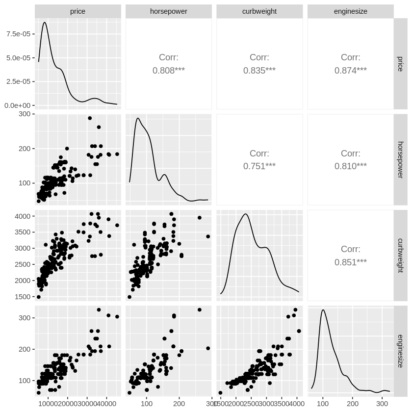

```python
install.packages("GGally")
# Load the GGally library for scatterplot matrix
library(GGally)

# Scatterplot Matrix
ggpairs(cp_info[, c("price", "horsepower", "curbweight", "enginesize")])
```

The below boxplot displays that price varies with different car body types, and it also displays price distribution. ggplot() function is used to create the basic plot and here the geom_boxplot() function is used to create the boxplot to that plot.

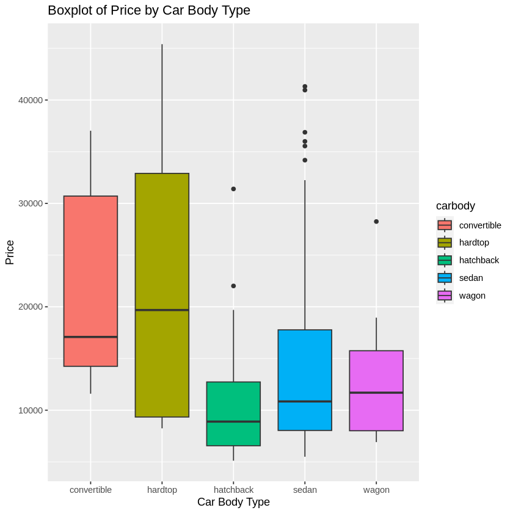

```python
# Boxplot of Price by Car Body Type
#aes is used for specifying the aesthetic mappings for the plot and the labs function is used for the addition of title and axis labels to the plot.
ggplot(cp_info, aes(x = carbody, y = price, fill = carbody)) +
  geom_boxplot() +
  labs(title = "Boxplot of Price by Car Body Type", x = "Car Body Type", y = "Price")
```

Histogram visualize the citympg which is the distribution of city miles per gallon. Each bar in the Histogram represents range of city miles per gallon.

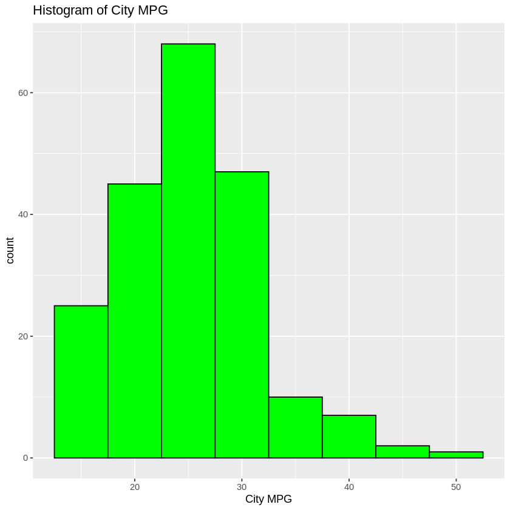

```python
# Histogram of City MPG
#aes is used for specifying the aesthetic mappings for the plot and the labs function is used for the addition of title and axis labels to the plot.

ggplot(cp_info, aes(x = citympg)) +
  geom_histogram(binwidth = 5, fill = "green", color = "black") +
  labs(title = "Histogram of City MPG", x = "City MPG")
```

Bar plot shows the count of each data type according to the distribution of fuel types.Each bar on the plot will represent to the unique fuel type. The height of the bar represents the count (frequency) of the fuel type.

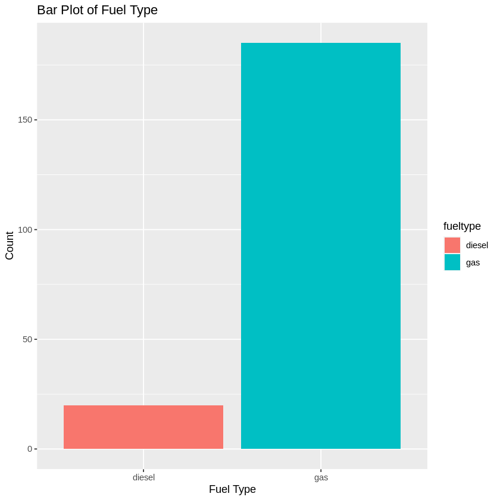

```python
# Bar Plot of Fuel Type
ggplot(cp_info, aes(x = fueltype, fill = fueltype)) +
  geom_bar() +
  labs(title = "Bar Plot of Fuel Type", x = "Fuel Type", y = "Count")
```

## 6. Explore Correlations

1. Scatter plot of price vs. horsepower:
- The below plot displays scatter plot between price which is the response variable and horsepower that is the predictor variable.
- Every point in the plot displays the car, horsepower on the x axis and price on the y axis.
1. Box plot of price by fuel type:
- The Box shows the distribution of price various fuel types like disel and gas.
- x axis has the type of gas and y axis has the price
1. Histogram of curbweight:
- Here curbweight is the weight of the car without occupants or baggage
- x axis represents curb weights, and y axis shows the count of cars.
1. Bar plot of Car Body types:
- This bar plot displays the count of cars for various body types.
- x axis represents car body types and y axis represents count of cars in each category

These visualization provide various aspects such as relationship b/w variables, price distribution by fuel type curb weight and car body types distribution.

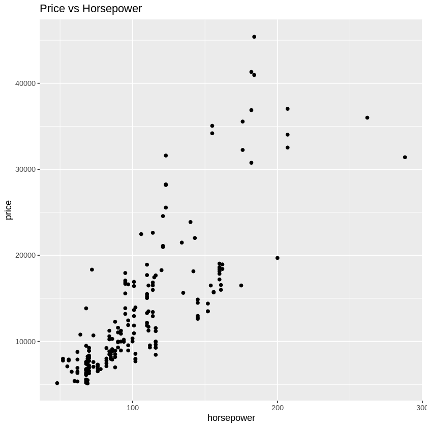

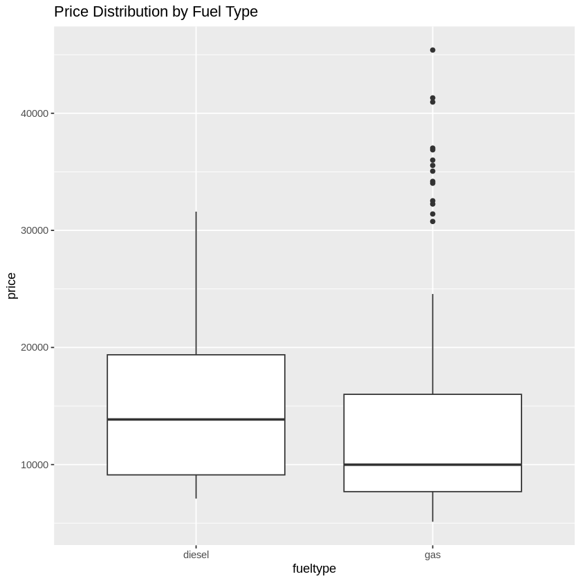

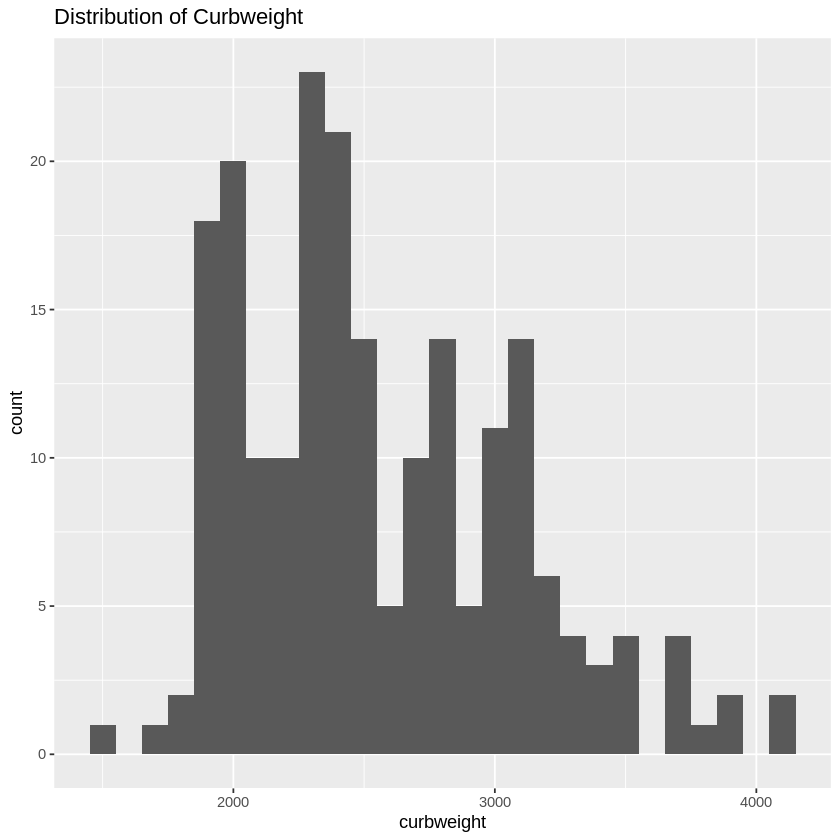

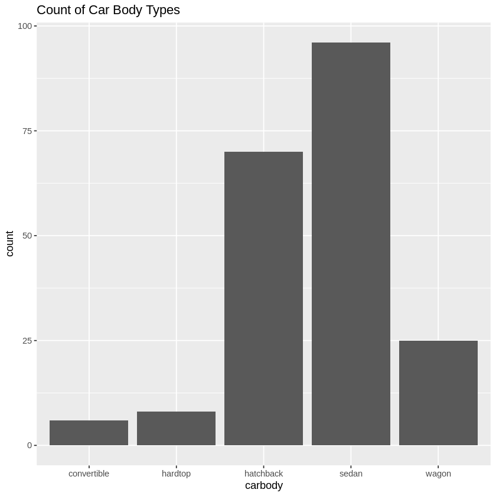

```python
library(ggplot2)

# 1. Scatter plot of price vs horsepower
ggplot(cp_info, aes(x=horsepower, y=price)) + geom_point() + ggtitle("Price vs Horsepower")

# 2. Box plot of price by fuel type
ggplot(cp_info, aes(x=fueltype, y=price)) + geom_boxplot() + ggtitle("Price Distribution by Fuel Type")

# 3. Histogram of curbweight
ggplot(cp_info, aes(x=curbweight)) + geom_histogram(binwidth=100) + ggtitle("Distribution of Curbweight")

# 4. Bar plot of car body types
ggplot(cp_info, aes(x=carbody)) + geom_bar() + ggtitle("Count of Car Body Types")
```

## 7. Response Variable:

The code that is shown is extracting of numeric continous variable. The code uses sapply() function along with is.numeric() to identify and select columns.which are continous numerical variables.

- I have selected the price column as my response variable.
  - price represents the price of the car in the dataset.
  - This variable represents monetary cost of the car, which is a continous numerical value.
  - As the price of the car is more precious to the sellers as well as buyers.
- I selected price as the response Variable because,
  - The choice of the price as the response variable is common in the context of car related datasets because its a important factor.
  - The common research question is the price of the cars nowadays,as it helps car manufacturers dealers and consumers understand what is the important factor car prices.
  - I can build a predective model to estimate car prices based on other attributes and features of the cars in the dataset.
- My expectations
  - In a linear regression analysis with price as the response variable, i would expect to find how various car attributes(predictor variables) relate to the price of the car.
  - I am expecting that factors like engine size , horsepower, carlength, car width,and other specifications have a significant impact on car prices.

```python
numerical_columns <- cp_info[, sapply(cp_info, is.numeric)]
head(numerical_columns)
```

A data.frame: 6 × 17

|  | symboling <int> | wheelbase <dbl> | carlength <dbl> | carwidth <dbl> | carheight <dbl> | curbweight <int> | enginesize <int> | boreratio <dbl> | stroke <dbl> | compressionratio <dbl> | horsepower <int> | peakrpm <int> | citympg <int> | highwaympg <int> | price <dbl> | performance_ratio <dbl> | avg_mpg <dbl> |
| --- | --- | --- | --- | --- | --- | --- | --- | --- | --- | --- | --- | --- | --- | --- | --- | --- | --- |
| 1 | 3 | 88.6 | 168.8 | 64.1 | 48.8 | 2548 | 130 | 3.47 | 2.68 | 9.0 | 111 | 5000 | 21 | 27 | 13495 | 0.04356358 | 24.0 |
| 2 | 3 | 88.6 | 168.8 | 64.1 | 48.8 | 2548 | 130 | 3.47 | 2.68 | 9.0 | 111 | 5000 | 21 | 27 | 16500 | 0.04356358 | 24.0 |
| 3 | 1 | 94.5 | 171.2 | 65.5 | 52.4 | 2823 | 152 | 2.68 | 3.47 | 9.0 | 154 | 5000 | 19 | 26 | 16500 | 0.05455190 | 22.5 |
| 4 | 2 | 99.8 | 176.6 | 66.2 | 54.3 | 2337 | 109 | 3.19 | 3.40 | 10.0 | 102 | 5500 | 24 | 30 | 13950 | 0.04364570 | 27.0 |
| 5 | 2 | 99.4 | 176.6 | 66.4 | 54.3 | 2824 | 136 | 3.19 | 3.40 | 8.0 | 115 | 5500 | 18 | 22 | 17450 | 0.04072238 | 20.0 |
| 6 | 2 | 99.8 | 177.3 | 66.3 | 53.1 | 2507 | 136 | 3.19 | 3.40 | 8.5 | 110 | 5500 | 19 | 25 | 15250 | 0.04387714 | 22.0 |

## 8. Simple Linear Regression

Here simple linear regression analysis performs five different predictor variables to predict the response variable price.

# Model 1

In this horsepower is choosen as predictor variable and the ultimate aim is to check the price.

- lm() function is used for linear regression, here price is regressed on horsepower using the data in the numerical columns.
- summary() function provides a summary for the model's results like coefficients, R- squared value, p- values.
- The coefficient for horsepower shows the estimated change in price for one unit increase in horsepower while keeping other variables constant.
- R-squared value shows difference in price for one unit increase in horsepower. A higher R-squared value indicates a better fit.
- p-value corelated with horsepower helps to estimate the statistical value of the predictor. A low p-value similar with horse power helps check out the statistical significance of the predictor of the price. *Illuminate the coefficient, R-squared value, and p-value to decide how well "horsepower" predicts "price."

# Model 2

Here in the model 2 plot, we will be predicting the dependent variable price based on the independent variable enginesize.

- In the residuals we get the difference between real and predicted values of the dependent variable. Here it also includes mean, standard error etc.
- The major thing in the summary is coefficient that helps us to understand the regression model.
- In the plot it displays Intercept as estimated coefficients and enginesize as independent variable.
- And for every coefficient there are estimated value, std.error, t value etc.
- So, the Intercept represents the estimated value of price when enginesize is zero(This might not have a meaningful interpretation in this context.)
- The plot helps us to asses how the independent variable enginesize explains the dependent variable prics.

# Model 3

In the model 3 plot we use curbweight as independent variable to predict the dependent variable price.

- This provides the statistics related to residuals.
- coefficient shows that estimated coefficents for the intercept and inndependent variable.(curbweight)
- it fits the simple linear regression model with curbweight as the independent variable to predict the price. *The model is the good fit and the significance of the independent variable.

# Model 4

In this model it creats the linear regression with the independent variable carlength to predict the dependent variable price,

# Model 5

Here the linear regression is created by using the independent variable citympg which is city miles per gallon.

- In this model the dependent variable is price based on the independent variable citympg.
- summary provides the various statistics of the regression model.
- The coefficient for citympg represents the estimated value change in price for one unit in citympg in this case it shows that how car fuel efficeincy affects the car orices.
- The independent variable citympg explains the variation in dependent variable price.
- This is a good fit and it shows the significance of the independent variable citympg.

```python
# Assuming your dataframe is named 'df'

# Model 1: Price ~ horsepower
model1 <- lm(price ~ horsepower, data = numerical_columns)
summary(model1)

# Model 2: Price ~ enginesize
model2 <- lm(price ~ enginesize, data = numerical_columns)
summary(model2)

# Model 3: Price ~ curbweight
model3 <- lm(price ~ curbweight, data = numerical_columns)
summary(model3)

# Model 4: Price ~ carlength
model4 <- lm(price ~ carlength, data = numerical_columns)
summary(model4)

# Model 5: Price ~ citympg
model5 <- lm(price ~ citympg, data = numerical_columns)
summary(model5)
```

```
Call:
lm(formula = price ~ horsepower, data = numerical_columns)

Residuals:
     Min       1Q   Median       3Q      Max
-11897.5  -2350.4   -711.1   1644.6  19081.4

Coefficients:
             Estimate Std. Error t value Pr(>|t|)
(Intercept) -3721.761    929.849  -4.003 8.78e-05 ***
horsepower    163.263      8.351  19.549  < 2e-16 ***
---
Signif. codes:  0 ‘***’ 0.001 ‘**’ 0.01 ‘*’ 0.05 ‘.’ 0.1 ‘ ’ 1

Residual standard error: 4717 on 203 degrees of freedom
Multiple R-squared:  0.6531,	Adjusted R-squared:  0.6514
F-statistic: 382.2 on 1 and 203 DF,  p-value: < 2.2e-16
```

```
Call:
lm(formula = price ~ enginesize, data = numerical_columns)

Residuals:
     Min       1Q   Median       3Q      Max
-10664.2  -2225.0   -482.4   1588.0  14271.5

Coefficients:
             Estimate Std. Error t value Pr(>|t|)
(Intercept) -8005.446    873.221  -9.168   <2e-16 ***
enginesize    167.698      6.539  25.645   <2e-16 ***
---
Signif. codes:  0 ‘***’ 0.001 ‘**’ 0.01 ‘*’ 0.05 ‘.’ 0.1 ‘ ’ 1

Residual standard error: 3889 on 203 degrees of freedom
Multiple R-squared:  0.7641,	Adjusted R-squared:  0.763
F-statistic: 657.6 on 1 and 203 DF,  p-value: < 2.2e-16
```

```
Call:
lm(formula = price ~ curbweight, data = numerical_columns)

Residuals:
     Min       1Q   Median       3Q      Max
-11604.4  -2042.4   -361.1   1368.3  20618.6

Coefficients:
              Estimate Std. Error t value Pr(>|t|)
(Intercept) -1.948e+04  1.544e+03  -12.61   <2e-16 ***
curbweight   1.282e+01  5.921e-01   21.65   <2e-16 ***
---
Signif. codes:  0 ‘***’ 0.001 ‘**’ 0.01 ‘*’ 0.05 ‘.’ 0.1 ‘ ’ 1

Residual standard error: 4403 on 203 degrees of freedom
Multiple R-squared:  0.6977,	Adjusted R-squared:  0.6962
F-statistic: 468.6 on 1 and 203 DF,  p-value: < 2.2e-16
```

```
Call:
lm(formula = price ~ carlength, data = numerical_columns)

Residuals:
   Min     1Q Median     3Q    Max
-11826  -3579  -1384   1968  26028

Coefficients:
            Estimate Std. Error t value Pr(>|t|)
(Intercept) -63690.7     5792.8  -10.99   <2e-16 ***
carlength      442.2       33.2   13.32   <2e-16 ***
---
Signif. codes:  0 ‘***’ 0.001 ‘**’ 0.01 ‘*’ 0.05 ‘.’ 0.1 ‘ ’ 1

Residual standard error: 5850 on 203 degrees of freedom
Multiple R-squared:  0.4664,	Adjusted R-squared:  0.4638
F-statistic: 177.4 on 1 and 203 DF,  p-value: < 2.2e-16
```

```
Call:
lm(formula = price ~ citympg, data = numerical_columns)

Residuals:
   Min     1Q Median     3Q    Max
 -9215  -3315  -1770   1974  22728

Coefficients:
            Estimate Std. Error t value Pr(>|t|)
(Intercept) 34395.44    1625.03   21.17   <2e-16 ***
citympg      -837.40      62.38  -13.42   <2e-16 ***
---
Signif. codes:  0 ‘***’ 0.001 ‘**’ 0.01 ‘*’ 0.05 ‘.’ 0.1 ‘ ’ 1

Residual standard error: 5829 on 203 degrees of freedom
Multiple R-squared:  0.4703,	Adjusted R-squared:  0.4676
F-statistic: 180.2 on 1 and 203 DF,  p-value: < 2.2e-16
```

Each scatterplot includes the data points and a blue regression line. which is created with geom_smooth. That represents the linear regression between the predictor variable and the response variable.

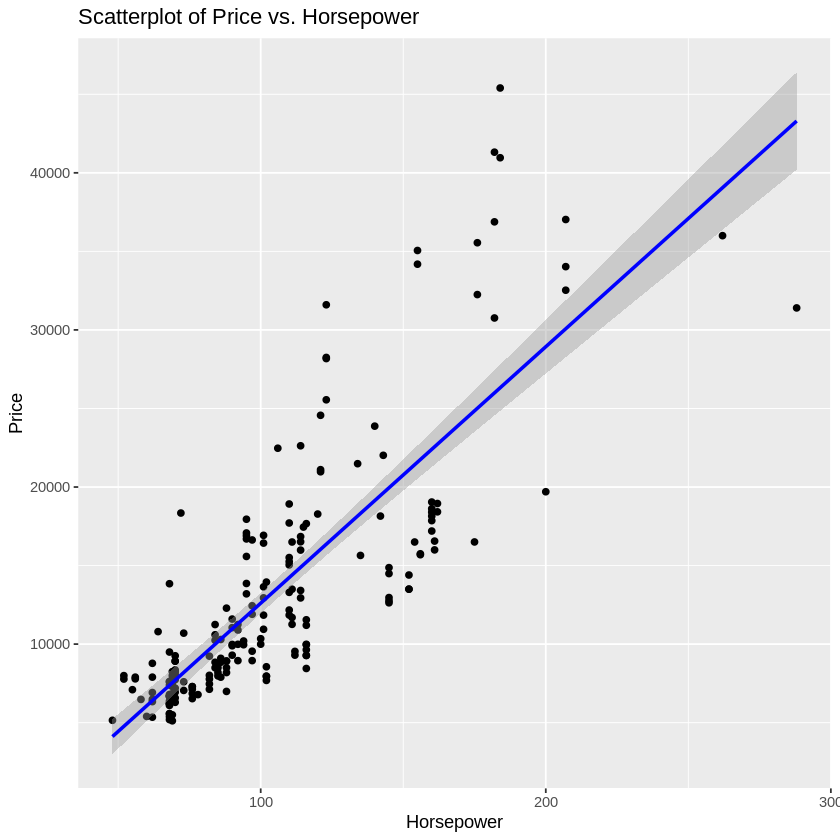

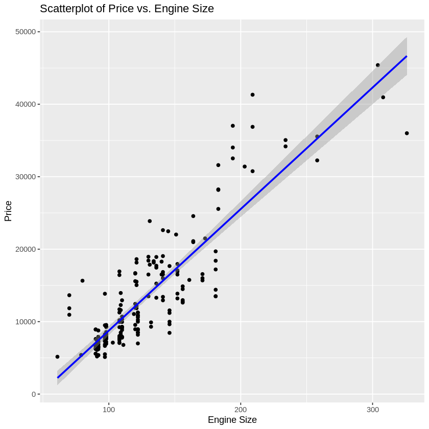

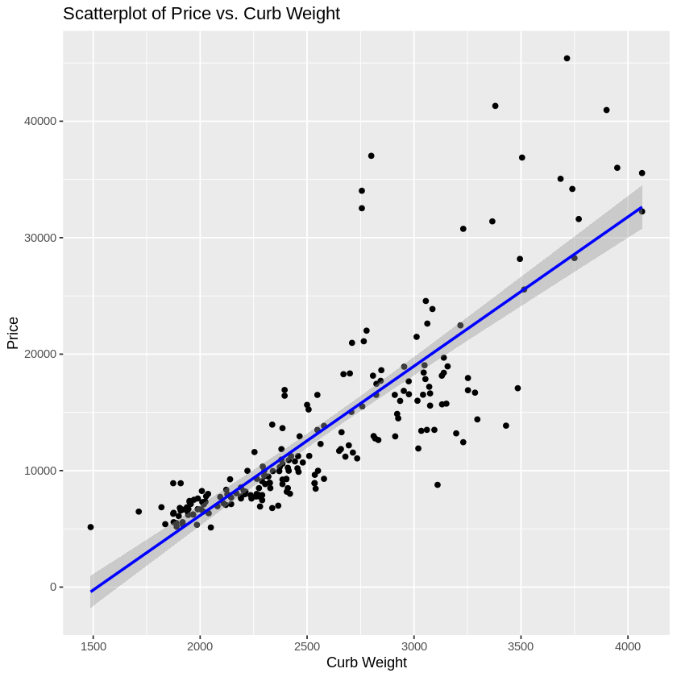

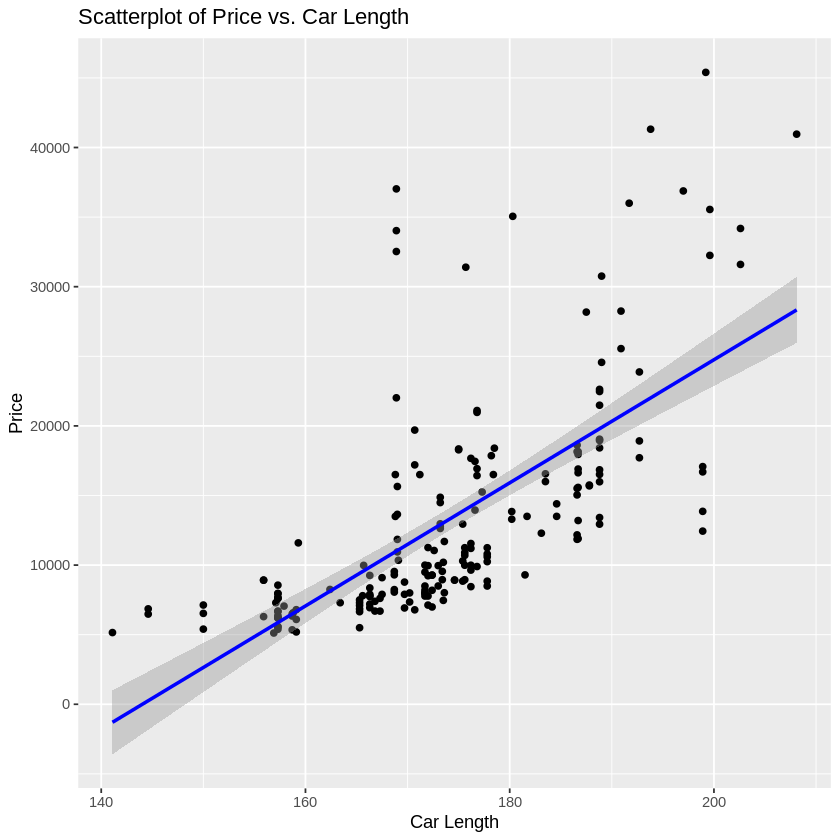

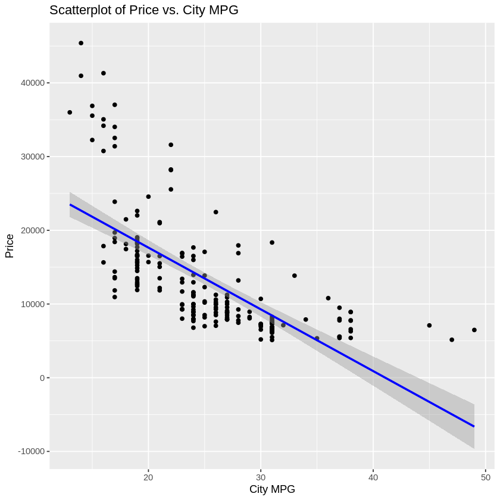

```python
# Load the necessary libraries
library(ggplot2)

# Scatterplot for Model 1: Price ~ horsepower
ggplot(numerical_columns, aes(x = horsepower, y = price)) +
  geom_point() +
  geom_smooth(method = "lm", color = "blue") +
  labs(title = "Scatterplot of Price vs. Horsepower", x = "Horsepower", y = "Price")

# Scatterplot for Model 2: Price ~ enginesize
ggplot(numerical_columns, aes(x = enginesize, y = price)) +
  geom_point() +
  geom_smooth(method = "lm", color = "blue") +
  labs(title = "Scatterplot of Price vs. Engine Size", x = "Engine Size", y = "Price")

# Scatterplot for Model 3: Price ~ curbweight
ggplot(numerical_columns, aes(x = curbweight, y = price)) +
  geom_point() +
  geom_smooth(method = "lm", color = "blue") +
  labs(title = "Scatterplot of Price vs. Curb Weight", x = "Curb Weight", y = "Price")

# Scatterplot for Model 4: Price ~ carlength
ggplot(numerical_columns, aes(x = carlength, y = price)) +
  geom_point() +
  geom_smooth(method = "lm", color = "blue") +
  labs(title = "Scatterplot of Price vs. Car Length", x = "Car Length", y = "Price")

# Scatterplot for Model 5: Price ~ citympg
ggplot(numerical_columns, aes(x = citympg, y = price)) +
  geom_point() +
  geom_smooth(method = "lm", color = "blue") +
  labs(title = "Scatterplot of Price vs. City MPG", x = "City MPG", y = "Price")
```

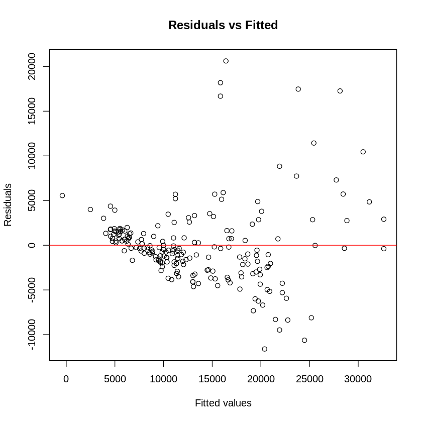

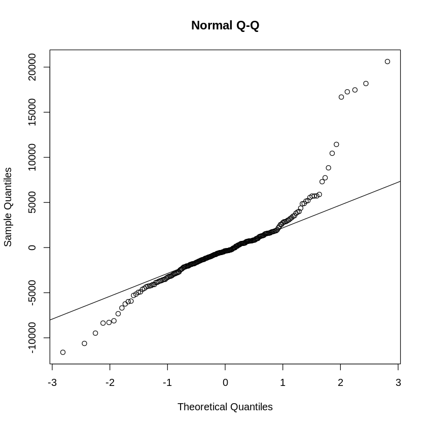

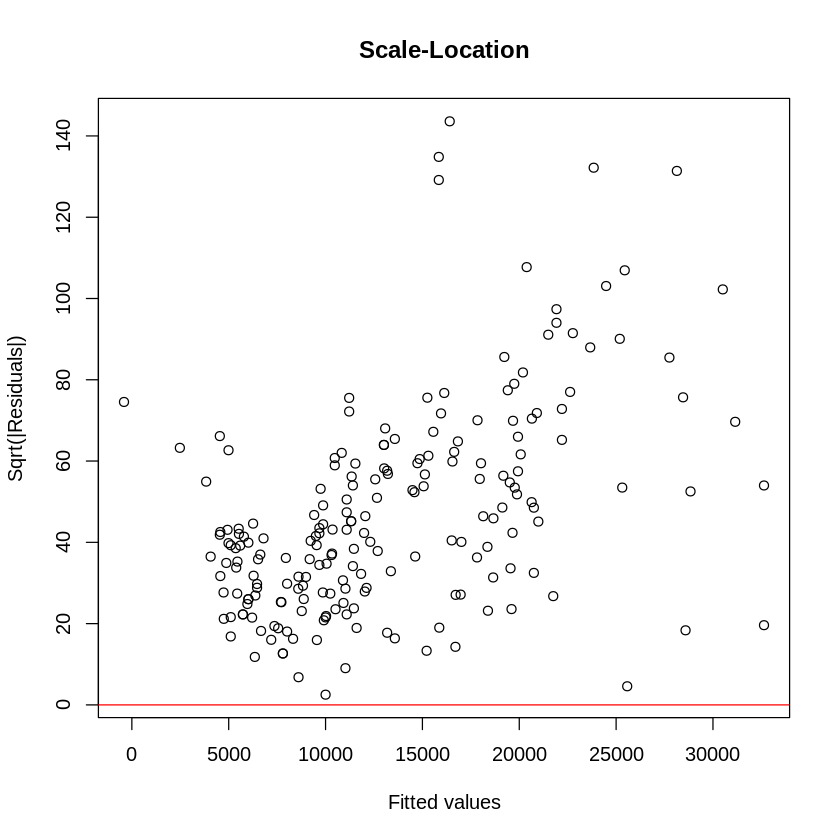

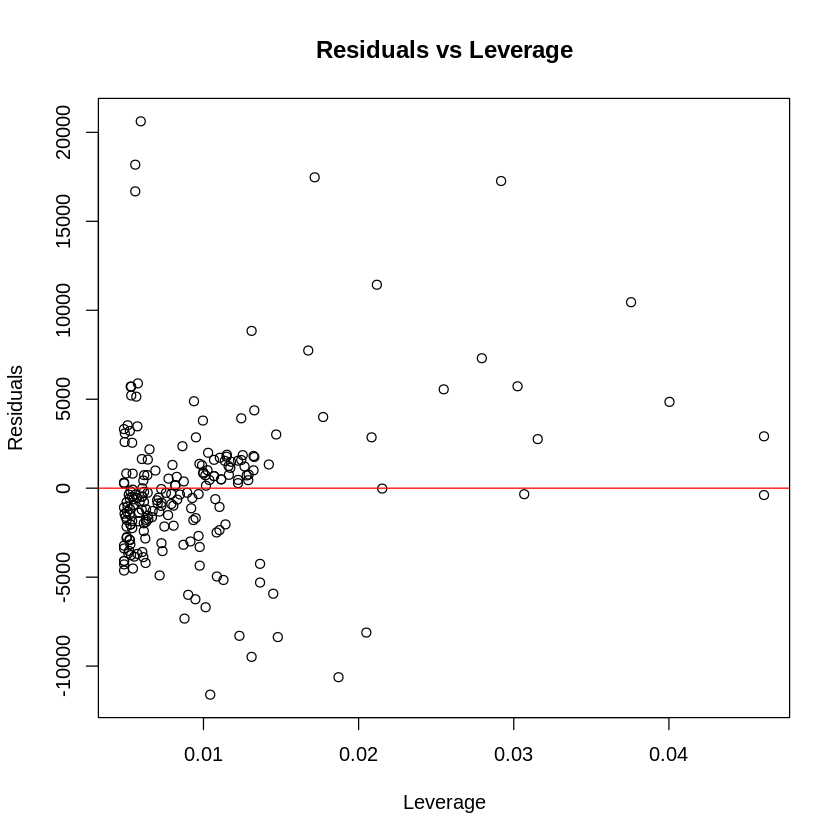

```python
model <- lm(price ~ curbweight, data = numerical_columns)

# Diagnostic Plots

# 1. Residuals vs Fitted values
plot(model$fitted.values, model$residuals, main="Residuals vs Fitted", xlab="Fitted values", ylab="Residuals")
abline(h=0, col="red")

# 2. Normal Q-Q plot
qqnorm(model$residuals, main="Normal Q-Q")
qqline(model$residuals)

# 3. Scale-Location (Spread vs Level)
plot(model$fitted.values, sqrt(abs(model$residuals)), main="Scale-Location", xlab="Fitted values", ylab="Sqrt(|Residuals|)")
abline(h=0, col="red")

# 4. Residuals vs Leverage
plot(hatvalues(model), model$residuals, main="Residuals vs Leverage", xlab="Leverage", ylab="Residuals")
abline(h=0, col="red")
```

## 9 Multiple Linear Regression:

- Here in the multi_model , we are creating a multiple linear regression modelto pridict the dependent variable price based on independent variables like horsepower, enginesize, curbweight,carlenght and citympg. This model provides info regarding the model's coefficients, statistical significance, R-squared value etc.
- In step wise regression, we are using the step() function. this is a very good technique for automatic variable selection. it removes or adds independent variables from the model based on the statistical data.This model describes about final selected model after the stepwise procedure including coefficients and statistical significance.
- Next is the plotting Diagnostic plots for the best simple model. This plot has a 2x2 grid for the best linear regression model.
- Plotting Diagnostic plots for the Multiple Linear Regression Model. This plot also sets 2x2 grid for multiple linear regression.

  # Interpretation and comparision in Multiple Linear Regression
- The Multiple Linear Regression model has the mixed effect of five independent variables(horsepower, enginesize,curbweight,carlength, citympg) on predicting the dependent variable (price).
- Stepwise regression (stepwise model) automatically selects a subset of independent variable.
- Diagnostic plots(residual plots) are used to assess the validity of the models and check if any assumptions of assumptions of linear regressions are met.
- The choice between the multiple regression model and a simple regression model depends on many factors.
- A multiple linear regression model can capture more complex relationships but it may require more complex data and assumptions. simple linear regression models are easier to interpret but may not capture all relevent factors.

```
Call:
lm(formula = price ~ horsepower + enginesize + curbweight + carlength +
    citympg, data = numerical_columns)

Residuals:
    Min      1Q  Median      3Q     Max
-8884.1 -1692.8   -89.2  1289.0 13650.4

Coefficients:
              Estimate Std. Error t value Pr(>|t|)
(Intercept) -17252.616   7139.068  -2.417 0.016567 *
horsepower      54.237     14.331   3.784 0.000204 ***
enginesize      82.976     13.558   6.120 4.88e-09 ***
curbweight       4.109      1.502   2.735 0.006793 **
carlength       16.464     45.339   0.363 0.716892
citympg         39.106     73.855   0.529 0.597051
---
Signif. codes:  0 ‘***’ 0.001 ‘**’ 0.01 ‘*’ 0.05 ‘.’ 0.1 ‘ ’ 1

Residual standard error: 3487 on 199 degrees of freedom
Multiple R-squared:  0.8141,	Adjusted R-squared:  0.8095
F-statistic: 174.3 on 5 and 199 DF,  p-value: < 2.2e-16
```

[output not shown]

[output cut: 158 more lines]

```
+ boreratio          1   9106900 1991874133 3316.3
+ horsepower         1   8146278 1992834755 3316.4
+ wheelbase          1   8117841 1992863192 3316.4
+ citympg            1   3409446 1997571587 3316.9
+ symboling          1   2537618 1998443415 3317.0
+ carlength          1   2238956 1998742077 3317.0
+ avg_mpg            1   1045104 1999935929 3317.1
+ highwaympg         1     38669 2000942364 3317.2
- carwidth           1  64377514 2065358547 3319.7
- performance_ratio  1  70763317 2071744350 3320.4
- curbweight         1  86352051 2087333084 3321.9
- compressionratio   1 140296778 2141277811 3327.1
- peakrpm            1 145875483 2146856516 3327.7
- stroke             1 158936249 2159917282 3328.9
- enginesize         1 844052728 2845033761 3385.4
```

```
Call:
lm(formula = price ~ carwidth + curbweight + enginesize + stroke +
    compressionratio + peakrpm + performance_ratio, data = numerical_columns)

Residuals:
     Min       1Q   Median       3Q      Max
-10703.1  -1667.6   -230.6   1591.7  14012.4

Coefficients:
                    Estimate Std. Error t value Pr(>|t|)
(Intercept)       -5.366e+04  1.225e+04  -4.379 1.93e-05 ***
carwidth           5.311e+02  2.110e+02   2.518 0.012614 *
curbweight         3.269e+00  1.121e+00   2.916 0.003960 **
enginesize         1.120e+02  1.229e+01   9.116  < 2e-16 ***
stroke            -2.949e+03  7.455e+02  -3.956 0.000106 ***
compressionratio   2.542e+02  6.840e+01   3.717 0.000263 ***
peakrpm            2.432e+00  6.417e-01   3.790 0.000200 ***
performance_ratio  9.802e+04  3.714e+04   2.639 0.008968 **
---
Signif. codes:  0 ‘***’ 0.001 ‘**’ 0.01 ‘*’ 0.05 ‘.’ 0.1 ‘ ’ 1

Residual standard error: 3187 on 197 degrees of freedom
Multiple R-squared:  0.8463,	Adjusted R-squared:  0.8408
F-statistic:   155 on 7 and 197 DF,  p-value: < 2.2e-16
```

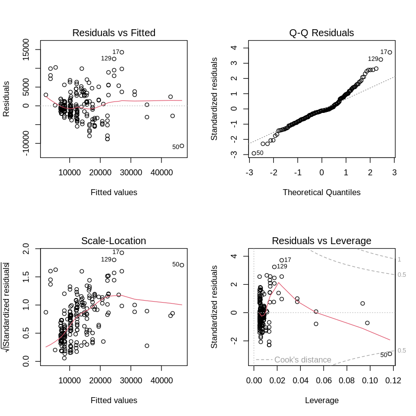

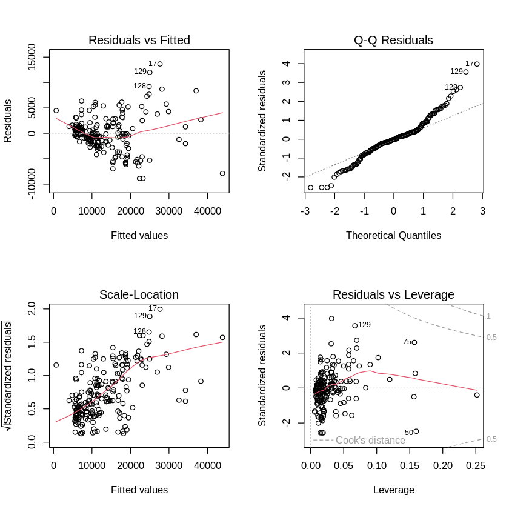

```python
# Model with multiple predictors
multi_model <- lm(price ~ horsepower + enginesize + curbweight + carlength + citympg, data = numerical_columns)
summary(multi_model)

stepwise_model <- step(lm(price ~ ., data = numerical_columns), direction = "both")
summary(stepwise_model)

# For the best simple model (let's assume model2 was the best)
par(mfrow=c(2,2))
plot(model2)

# For the multiple regression model
par(mfrow=c(2,2))
plot(multi_model)
```

## 10. Project Report

To begin our adventure, we carefully examined the dataset's structure, variables, and distributions. Key characteristics such as horsepower, curb weight, and fuel economy were of special importance since they frequently play key roles in affecting automobile costs. This first data investigation established the framework.

In order to improve the dataset's insights, we included computed features such as 'performance_ratio' and 'avg_mpg'. These extra articles offered distinct viewpoints on a car's performance and energy efficiency, two essential considerations in a consumer's decision-making process. 'Performance_ratio' provided information on the horsepower to weight ratio, which reflects a car's performance, while 'avg_mpg' provided an average estimate of fuel economy, combining city and highway MPG statistics. The chosen response variable, automobile pricing, is extremely important in the automotive industry. A crucial component for allowing the best pricing techniques and market positioning is the accurate projection of automotive prices. In order to develop the most precise prediction model, we explored basic and multivariate linear regression models to forecast automobile prices based on numerous parameters.

In summary, this study provides priceless information that can influence pricing policies, product advancement, and market competitiveness. Utilizing these findings, we suggest adjusting pricing policies, placing a stronger emphasis on high-performance features, and giving fuel economy first priority in order to appeal to customer desires and stand out in the crowded car market.

[figure not shown]

# "No other similar published works for linear regression found with same dataset"